# NYC311 Customer Service Analysis R

Malay Raj

2023-06-12

## NYC 311 CUSTOMER SERVICE REPORT ANALYSIS.

Problem Objective :

Perform a service request data analysis of New York City 311 calls. You will focus on the data wrangling techniques to understand the pattern in the data and also visualize the major complaint types.

For this analysis I haven’t included the null values.

Domain: Customer Service

## Loading Required Packages.

```r
library(tidyverse)
library(janitor)
```

```r
library(dplyr)
library(ggplot2)
library(skimr)
library(plyr)
library(lubridate)
library(scales)
```

## Displaying my current working directory.

```r
getwd()
```

```
## [1] "C:/Users/KIIT/OneDrive/Desktop/Bellabeat/NYC Customer Service Requests Analysis"
```

## Collecting the data.

```r
NYC = read.csv("C:/Users/KIIT/OneDrive/Desktop/Bellabeat/NYC Customer Service Requests Analysis/NYC311data.csv")
```

## Displaying the first six rows of the dataset.

```r
head(NYC)
```

```
##   Unique.Key           Created.Date   Closed.Date Agency
## 1   32310363 12/31/2015 11:59:45 PM 01-01-16 0:55   NYPD
## 2   32309934 12/31/2015 11:59:44 PM 01-01-16 1:26   NYPD
## 3   32309159 12/31/2015 11:59:29 PM 01-01-16 4:51   NYPD
## 4   32305098 12/31/2015 11:57:46 PM 01-01-16 7:43   NYPD
## 5   32306529 12/31/2015 11:56:58 PM 01-01-16 3:24   NYPD
## 6   32306554 12/31/2015 11:56:30 PM 01-01-16 1:50   NYPD
##                       Agency.Name          Complaint.Type
## 1 New York City Police Department Noise - Street/Sidewalk
## 2 New York City Police Department        Blocked Driveway
## 3 New York City Police Department        Blocked Driveway
## 4 New York City Police Department         Illegal Parking
## 5 New York City Police Department         Illegal Parking
## 6 New York City Police Department         Illegal Parking
##                      Descriptor   Location.Type Incident.Zip
```

[output cut: 97 more lines]

## Checking the number of rows and dimension of the dataset.

```r
nrow(NYC)
```

```
## [1] 300698
```

```r
dim(NYC)
```

```
## [1] 300698     53
```

## Renaming few columns which we further need in analysis.

```r
NYC=plyr::rename(NYC, replace=c("Unique.Key" = "Unique_key",
                                "Created.Date" = "Created_date",
                                "Closed.Date" = "Closed_date",
                                "Location.Type" = "Location_type",
                                "Incident.Zip" = "Incident_zip",
                                "Complaint.Type" = "Complaint_type",
                                "Resolution.Action.Updated.Date" = "Updated_closed_date",
                                "Incident.Address" = "Incident_address",
                                "Address.Type" = "Address_type",
                                "Due.Date" = "Due_date",
                                "Community.Board" = "Community_board",
                                "X.Coordinate..State.Plane." = "X_coordinate",
                                "Y.Coordinate..State.Plane." = "Y_coordinate"))
```

## Viewing the new column names.

```r
colnames(NYC)
```

```
##  [1] "Unique_key"                   "Created_date"
##  [3] "Closed_date"                  "Agency"
##  [5] "Agency.Name"                  "Complaint_type"
##  [7] "Descriptor"                   "Location_type"
##  [9] "Incident_zip"                 "Incident_address"
## [11] "Street.Name"                  "Cross.Street.1"
## [13] "Cross.Street.2"               "Intersection.Street.1"
## [15] "Intersection.Street.2"        "Address_type"
## [17] "City"                         "Landmark"
## [19] "Facility.Type"                "Status"
## [21] "Due_date"                     "Resolution.Description"
## [23] "Updated_closed_date"          "Community_board"
## [25] "Borough"                      "X_coordinate"
## [27] "Y_coordinate"                 "Park.Facility.Name"
## [29] "Park.Borough"                 "School.Name"
## [31] "School.Number"                "School.Region"
## [33] "School.Code"                  "School.Phone.Number"
## [35] "School.Address"               "School.City"
## [37] "School.State"                 "School.Zip"
## [39] "School.Not.Found"             "School.or.Citywide.Complaint"
## [41] "Vehicle.Type"                 "Taxi.Company.Borough"
## [43] "Taxi.Pick.Up.Location"        "Bridge.Highway.Name"
## [45] "Bridge.Highway.Direction"     "Road.Ramp"
## [47] "Bridge.Highway.Segment"       "Garage.Lot.Name"
## [49] "Ferry.Direction"              "Ferry.Terminal.Name"
## [51] "Latitude"                     "Longitude"
## [53] "Location"
```

## Inspecting the dataframe and look for inconguencies.

```r
str(NYC)
```

```
## 'data.frame':    300698 obs. of  53 variables:
##  $ Unique_key                  : int  32310363 32309934 32309159 32305098 32306529 32306554 32306559 32307009 32308581 32308391 ...
##  $ Created_date                : chr  "12/31/2015 11:59:45 PM" "12/31/2015 11:59:44 PM" "12/31/2015 11:59:29 PM" "12/31/2015 11:57:46 PM" ...
##  $ Closed_date                 : chr  "01-01-16 0:55" "01-01-16 1:26" "01-01-16 4:51" "01-01-16 7:43" ...
##  $ Agency                      : chr  "NYPD" "NYPD" "NYPD" "NYPD" ...
##  $ Agency.Name                 : chr  "New York City Police Department" "New York City Police Department" "New York City Police Department" "New York City Police Department" ...
##  $ Complaint_type              : chr  "Noise - Street/Sidewalk" "Blocked Driveway" "Blocked Driveway" "Illegal Parking" ...
##  $ Descriptor                  : chr  "Loud Music/Party" "No Access" "No Access" "Commercial Overnight Parking" ...
##  $ Location_type               : chr  "Street/Sidewalk" "Street/Sidewalk" "Street/Sidewalk" "Street/Sidewalk" ...
##  $ Incident_zip                : chr  "10034" "11105" "10458" "10461" ...
##  $ Incident_address            : chr  "71 VERMILYEA AVENUE" "27-07 23 AVENUE" "2897 VALENTINE AVENUE" "2940 BAISLEY AVENUE" ...
##  $ Street.Name                 : chr  "VERMILYEA AVENUE" "23 AVENUE" "VALENTINE AVENUE" "BAISLEY AVENUE" ...
##  $ Cross.Street.1              : chr  "ACADEMY STREET" "27 STREET" "EAST 198 STREET" "EDISON AVENUE" ...
##  $ Cross.Street.2              : chr  "WEST 204 STREET" "28 STREET" "EAST 199 STREET" "B STREET" ...
##  $ Intersection.Street.1       : chr  "" "" "" "" ...
```

[output cut: 39 more lines]

## Changing datatypes of Created_date, Closed_date, Updated_closed_date and Due_date. All in one single format.

```r
NYC$Created_date <- as.POSIXct(NYC$Created_date, format = "%m/%d/%Y %I:%M:%S %p")
NYC$Closed_date <- as.POSIXct(NYC$Closed_date, format = "%m-%d-%y %H:%M")
NYC$Updated_closed_date <- as.POSIXct(NYC$Updated_closed_date, format = "%m-%d-%y %H:%M")
NYC$Due_date <- as.POSIXct(NYC$Due_date, format = "%m-%d-%y %H:%M")
```

## Checking if they are changed or not.

```r
str(NYC)
```

```
## 'data.frame':    300698 obs. of  53 variables:
##  $ Unique_key                  : int  32310363 32309934 32309159 32305098 32306529 32306554 32306559 32307009 32308581 32308391 ...
##  $ Created_date                : POSIXct, format: "2015-12-31 23:59:45" "2015-12-31 23:59:44" ...
##  $ Closed_date                 : POSIXct, format: "2016-01-01 00:55:00" "2016-01-01 01:26:00" ...
##  $ Agency                      : chr  "NYPD" "NYPD" "NYPD" "NYPD" ...
##  $ Agency.Name                 : chr  "New York City Police Department" "New York City Police Department" "New York City Police Department" "New York City Police Department" ...
##  $ Complaint_type              : chr  "Noise - Street/Sidewalk" "Blocked Driveway" "Blocked Driveway" "Illegal Parking" ...
##  $ Descriptor                  : chr  "Loud Music/Party" "No Access" "No Access" "Commercial Overnight Parking" ...
##  $ Location_type               : chr  "Street/Sidewalk" "Street/Sidewalk" "Street/Sidewalk" "Street/Sidewalk" ...
##  $ Incident_zip                : chr  "10034" "11105" "10458" "10461" ...
##  $ Incident_address            : chr  "71 VERMILYEA AVENUE" "27-07 23 AVENUE" "2897 VALENTINE AVENUE" "2940 BAISLEY AVENUE" ...
##  $ Street.Name                 : chr  "VERMILYEA AVENUE" "23 AVENUE" "VALENTINE AVENUE" "BAISLEY AVENUE" ...
##  $ Cross.Street.1              : chr  "ACADEMY STREET" "27 STREET" "EAST 198 STREET" "EDISON AVENUE" ...
##  $ Cross.Street.2              : chr  "WEST 204 STREET" "28 STREET" "EAST 199 STREET" "B STREET" ...
##  $ Intersection.Street.1       : chr  "" "" "" "" ...
```

[output cut: 39 more lines]

## Dropping few columns because we don’t need them in our further analysis.

```r
NYC = subset(NYC, select = -c(Agency, Closed_date, Agency.Name, Street.Name, Cross.Street.1, Cross.Street.2, Intersection.Street.1, Intersection.Street.2, Landmark, Facility.Type, Status, Resolution.Description, Park.Borough, Park.Facility.Name, School.Name, Incident_zip, Incident_address, School.Number, School.State, School.Region, School.Code, School.Phone.Number, School.Address, School.City, School.Zip, School.Not.Found, School.or.Citywide.Complaint, Vehicle.Type, Taxi.Company.Borough, Taxi.Pick.Up.Location, Bridge.Highway.Name, Bridge.Highway.Direction, Road.Ramp, Bridge.Highway.Segment, Garage.Lot.Name, Ferry.Direction, Ferry.Terminal.Name, Location))
```

## Checking the column names which are left for analysis.

```r
colnames(NYC)
```

```
##  [1] "Unique_key"          "Created_date"        "Complaint_type"
##  [4] "Descriptor"          "Location_type"       "Address_type"
##  [7] "City"                "Due_date"            "Updated_closed_date"
## [10] "Community_board"     "Borough"             "X_coordinate"
## [13] "Y_coordinate"        "Latitude"            "Longitude"
```

## Creating a new column request_closing_time with the difference of Updated_closed_date and Created_date.

```r
NYC$request_closing_time <- difftime(NYC$Updated_closed_date,NYC$Created_date)
```

## Changing the datatype of the new column ‘request_closing_time’ to numeric.

```r
NYC$request_closing_time <- as.numeric(NYC$request_closing_time)
```

## Checking the final dimensions which we need in analysis.

```r
dim(NYC)
```

```
## [1] 300698     16
```

## Checking for duplicate values in our dataframe.

```r
anyDuplicated(NYC)
```

```
## [1] 0
```

## Checking for null values in our dataset.

```r
sum(is.na(NYC))
```

```
## [1] 798328
```

## Dropping all the null values.

```r
NYC <- NYC[complete.cases(NYC), ]
```

## Checking the current dimensions after dropping all the null values.

```r
dim(NYC)
```

```
## [1] 1842   16
```

## Seeing how many observations fall under each of these columns.

```r
table(NYC$Complaint_type)
```

```
##
##              Animal Abuse Bike/Roller/Skate Chronic          Blocked Driveway
##                        36                         3                       523
##          Derelict Vehicle          Disorderly Youth                  Drinking
##                        80                         5                         6
##                  Graffiti       Homeless Encampment         Illegal Fireworks
##                         2                        14                         2
##           Illegal Parking        Noise - Commercial  Noise - House of Worship
##                       445                       272                         3
##              Noise - Park   Noise - Street/Sidewalk           Noise - Vehicle
##                        15                       303                        91
##     Posting Advertisement                   Traffic       Urinating in Public
##                        15                        15                         3
##                   Vending
##                         9
```

```r
table(NYC$Descriptor)
```

```
##
##               Banging/Pounding                Blocked Hydrant
##                             18                            110
##               Blocked Sidewalk                 Car/Truck Horn
##                             51                             16
##                Car/Truck Music                        Chained
##                             59                              2
##   Commercial Overnight Parking            Congestion/Gridlock
##                            138                              8
##               Detached Trailer Double Parked Blocking Traffic
##                              1                             22
## Double Parked Blocking Vehicle                    Drag Racing
##                              9                              3
##                  Engine Idling                         In Car
##                             20                              1
##             In Prohibited Area                      In Public
##                              5                              5
##               Loud Music/Party                   Loud Talking
##                            427                            144
##                            N/A                      Neglected
##                             22                             11
##                      No Access                     No Shelter
##                            371                              3
##                Nuisance/Truant      Other (complaint details)
##                              1                             13
##   Overnight Commercial Storage                 Partial Access
##                             16                            152
##    Playing in Unsuitable Place        Police Report Requested
##                              4                              2
##  Posted Parking Sign Violation                       Tortured
##                             91                              6
##          Truck Route Violation       Unauthorized Bus Layover
##                              4                              7
##        Underage - Licensed Est                     Unlicensed
##                              1                              4
##                        Vehicle             With License Plate
##                             15                             80
```

```r
table(NYC$Location_type)
```

```
##
##        Club/Bar/Restaurant                 Commercial
##                        155                          1
##                    Highway            House and Store
##                          1                          2
##           House of Worship            Park/Playground
##                          3                         17
## Residential Building/House           Store/Commercial
##                         33                        124
##            Street/Sidewalk             Subway Station
##                       1505                          1
```

```r
table(NYC$Address_type)
```

```
##
##                   ADDRESS    BLOCKFACE INTERSECTION      LATLONG
##            1         1573           34          207           27
```

```r
table(NYC$Community_board)
```

```
##
##         01 BRONX      01 BROOKLYN     01 MANHATTAN        01 QUEENS
##                8               76               14               72
## 01 STATEN ISLAND         02 BRONX      02 BROOKLYN     02 MANHATTAN
##               23                7               14               29
##        02 QUEENS 02 STATEN ISLAND         03 BRONX      03 BROOKLYN
##               40               22               17               28
##     03 MANHATTAN        03 QUEENS 03 STATEN ISLAND         04 BRONX
##               44               30               42               36
##      04 BROOKLYN     04 MANHATTAN        04 QUEENS         05 BRONX
##                9               31               51               34
##      05 BROOKLYN     05 MANHATTAN        05 QUEENS         06 BRONX
##               23               12               86               20
##      06 BROOKLYN     06 MANHATTAN        06 QUEENS         07 BRONX
##               17               35               27               41
```

[output cut: 16 more lines]

```r
table(NYC$Borough)
```

```
##
##         BRONX      BROOKLYN     MANHATTAN        QUEENS STATEN ISLAND
##           320           539           346           550            87
```

## CONDUCTNG DESCRIPTIVE ANALYSIS:

Descriptive analysis on whole NYC dataframe at once.

```r
summary(NYC)
```

```
##    Unique_key        Created_date                    Complaint_type
##  Min.   :30298181   Min.   :2015-03-31 16:21:59.00   Length:1842
##  1st Qu.:30741718   1st Qu.:2015-05-31 23:44:54.50   Class :character
##  Median :31210056   Median :2015-07-31 23:34:47.50   Mode  :character
##  Mean   :31296594   Mean   :2015-08-14 00:31:56.71
##  3rd Qu.:31881600   3rd Qu.:2015-10-31 20:11:31.25
##  Max.   :32310640   Max.   :2015-12-31 23:59:45.00
##   Descriptor        Location_type      Address_type           City
##  Length:1842        Length:1842        Length:1842        Length:1842
##  Class :character   Class :character   Class :character   Class :character
##  Mode  :character   Mode  :character   Mode  :character   Mode  :character
##
##
##
##     Due_date                      Updated_closed_date
##  Min.   :2015-04-01 00:21:00.00   Min.   :2015-04-01 00:00:00.00
##  1st Qu.:2015-06-01 07:44:30.00   1st Qu.:2015-06-01 07:45:45.00
##  Median :2015-08-01 07:34:00.00   Median :2015-08-01 04:54:30.00
##  Mean   :2015-08-14 08:31:27.75   Mean   :2015-08-14 07:01:19.08
##  3rd Qu.:2015-11-01 04:10:45.00   3rd Qu.:2015-11-01 00:52:30.00
##  Max.   :2016-01-01 07:59:00.00   Max.   :2016-01-03 16:22:00.00
##  Community_board      Borough           X_coordinate      Y_coordinate
##  Length:1842        Length:1842        Min.   : 917482   Min.   :122688
##  Class :character   Class :character   1st Qu.: 993216   1st Qu.:181806
##  Mode  :character   Mode  :character   Median :1005457   Median :203228
##                                        Mean   :1005545   Mean   :204960
##                                        3rd Qu.:1020089   3rd Qu.:231581
##                                        Max.   :1065122   Max.   :270185
##     Latitude       Longitude      request_closing_time
##  Min.   :40.50   Min.   :-74.24   Min.   :  11.23
##  1st Qu.:40.67   1st Qu.:-73.97   1st Qu.: 168.15
##  Median :40.72   Median :-73.92   Median : 307.60
##  Mean   :40.73   Mean   :-73.92   Mean   : 389.37
##  3rd Qu.:40.80   3rd Qu.:-73.87   3rd Qu.: 491.18
##  Max.   :40.91   Max.   :-73.71   Max.   :3939.63
```

## SUMMARY STATISTICS.

```r
skimr::skim_without_charts(NYC)
```

Data summary

| Name | NYC |
| --- | --- |
| Number of rows | 1842 |
| Number of columns | 16 |
| _______________________ |  |
| Column type frequency: |  |
| character | 7 |
| numeric | 6 |
| POSIXct | 3 |
| ________________________ |  |
| Group variables | None |

**Variable type: character**

| skim_variable | n_missing | complete_rate | min | max | empty | n_unique | whitespace |
| --- | --- | --- | --- | --- | --- | --- | --- |
| Complaint_type | 0 | 1 | 7 | 25 | 0 | 19 | 0 |
| Descriptor | 0 | 1 | 3 | 30 | 0 | 36 | 0 |
| Location_type | 0 | 1 | 7 | 26 | 0 | 10 | 0 |
| Address_type | 0 | 1 | 0 | 12 | 1 | 5 | 0 |
| City | 0 | 1 | 5 | 19 | 0 | 47 | 0 |
| Community_board | 0 | 1 | 8 | 16 | 0 | 60 | 0 |
| Borough | 0 | 1 | 5 | 13 | 0 | 5 | 0 |

**Variable type: numeric**

| skim_variable | n_missing | complete_rate | mean | sd | p0 | p25 | p50 | p75 | p100 |
| --- | --- | --- | --- | --- | --- | --- | --- | --- | --- |
| Unique_key | 0 | 1 | 31296594.35 | 594961.54 | 30298181.00 | 30741717.50 | 31210056.00 | 31881599.50 | 32310640.00 |
| X_coordinate | 0 | 1 | 1005545.41 | 22724.18 | 917482.00 | 993215.50 | 1005456.50 | 1020088.75 | 1065122.00 |
| Y_coordinate | 0 | 1 | 204959.56 | 31527.91 | 122688.00 | 181805.50 | 203227.50 | 231580.50 | 270185.00 |
| Latitude | 0 | 1 | 40.73 | 0.09 | 40.50 | 40.67 | 40.72 | 40.80 | 40.91 |
| Longitude | 0 | 1 | -73.92 | 0.08 | -74.24 | -73.97 | -73.92 | -73.87 | -73.71 |
| request_closing_time | 0 | 1 | 389.37 | 347.87 | 11.23 | 168.15 | 307.60 | 491.17 | 3939.63 |

**Variable type: POSIXct**

| skim_variable | n_missing | complete_rate | min | max | median | n_unique |
| --- | --- | --- | --- | --- | --- | --- |
| Created_date | 0 | 1 | 2015-03-31 16:21:59 | 2015-12-31 23:59:45 | 2015-07-31 23:34:47 | 1831 |
| Due_date | 0 | 1 | 2015-04-01 00:21:00 | 2016-01-01 07:59:00 | 2015-08-01 07:34:00 | 1384 |
| Updated_closed_date | 0 | 1 | 2015-04-01 00:00:00 | 2016-01-03 16:22:00 | 2015-08-01 04:54:30 | 1213 |

## DATA VISUALIZATION:

Checking the complaint types of each city.

[figure not shown]

```r
ggplot(NYC) +
  geom_col(mapping = aes(x=City, y=Complaint_type, fill=Complaint_type)) +
  theme(legend.key.size = unit(0.3, "cm")) +
  labs(title="Complains VS City")
```

Checking for the location type where most of the complains come.

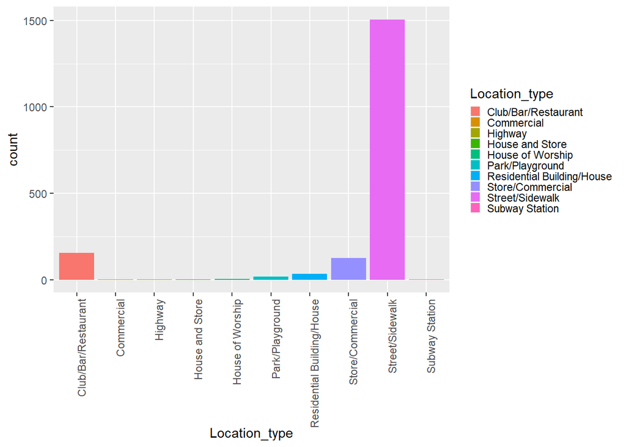

```r
ggplot(NYC, aes(Location_type, fill = Location_type)) +
  geom_bar() +
  theme(legend.key.size = unit(0.3, "cm")) +
  theme(axis.text.x = element_text(angle = 90, hjust = 1))
```

## As we saw from the first visualization the most of the complains are from ‘Brooklyn’ city.

Let’s check which type of complains comes most from that city.

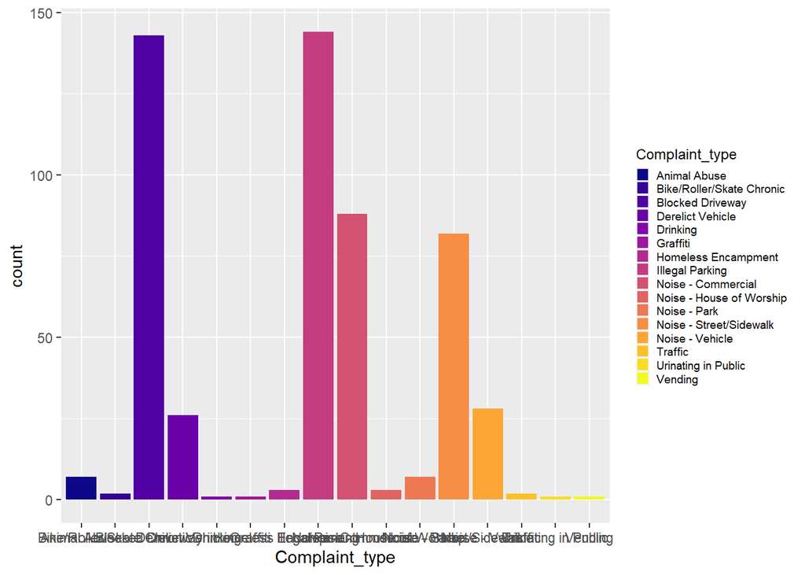

```r
NYC %>%
  filter(City == 'BROOKLYN') %>%
  ggplot(aes(x = Complaint_type, fill = Complaint_type)) +
  geom_bar() +
  scale_fill_viridis_d(option = "plasma", guide = "legend") +
  theme(legend.text = element_text(size = 7),
        legend.title = element_text(size = 9),
        legend.key.size = unit(0.3, "cm"))
```

[figure not shown]

```r
ggplot(NYC, aes(x = Borough, y = request_closing_time, fill = Borough)) +
  geom_bar(stat = 'identity') +
  labs(title = 'Average Request Closing Time for Boroughs') +
  theme_bw() +
  scale_y_continuous(labels = scales::comma)
```

## Checking whether the response time across complaint types is similar or not.

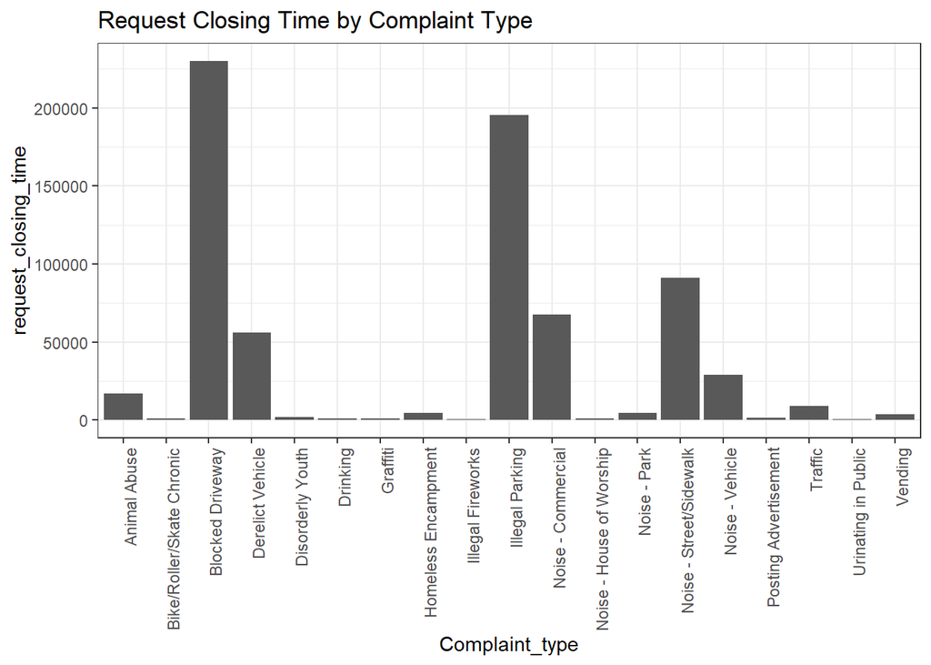

```r
ggplot(NYC, aes(x = Complaint_type, y = request_closing_time)) +
  geom_bar(stat = 'identity') +
  labs(title = 'Request Closing Time by Complaint Type') +
  theme_bw() +
  theme(axis.text.x = element_text(angle = 90, hjust = 1))
```

Also checking for the average of response time across complaint types is similar or not.

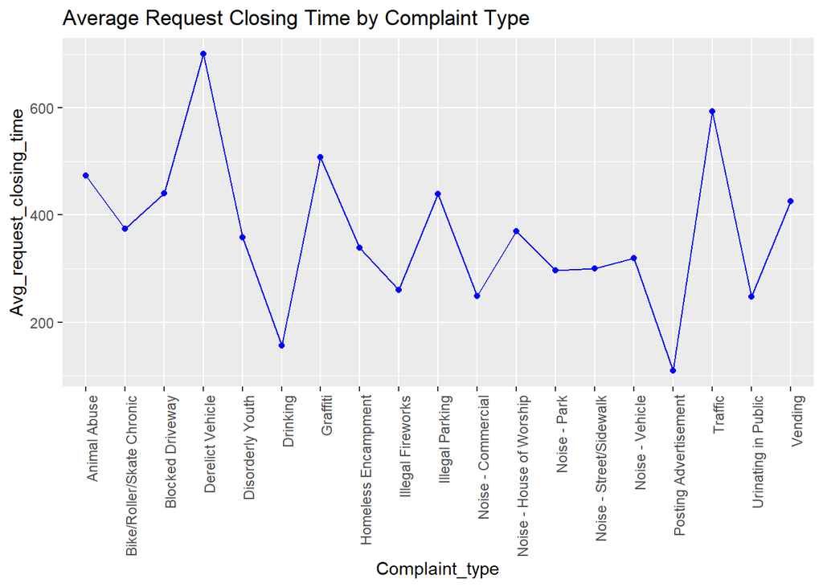

```r
avg_request_closing_time <- aggregate(request_closing_time ~ Complaint_type, data = NYC, FUN = mean)
ggplot(avg_request_closing_time, aes(x = Complaint_type, y = request_closing_time)) +
  geom_point(color = "blue") +
  geom_line(color = "blue", group = 1) +
  labs(title = 'Average Request Closing Time by Complaint Type', x = 'Complaint_type', y = 'Avg_request_closing_time') +
  theme(axis.text.x = element_text(angle = 90, hjust = 1))
```

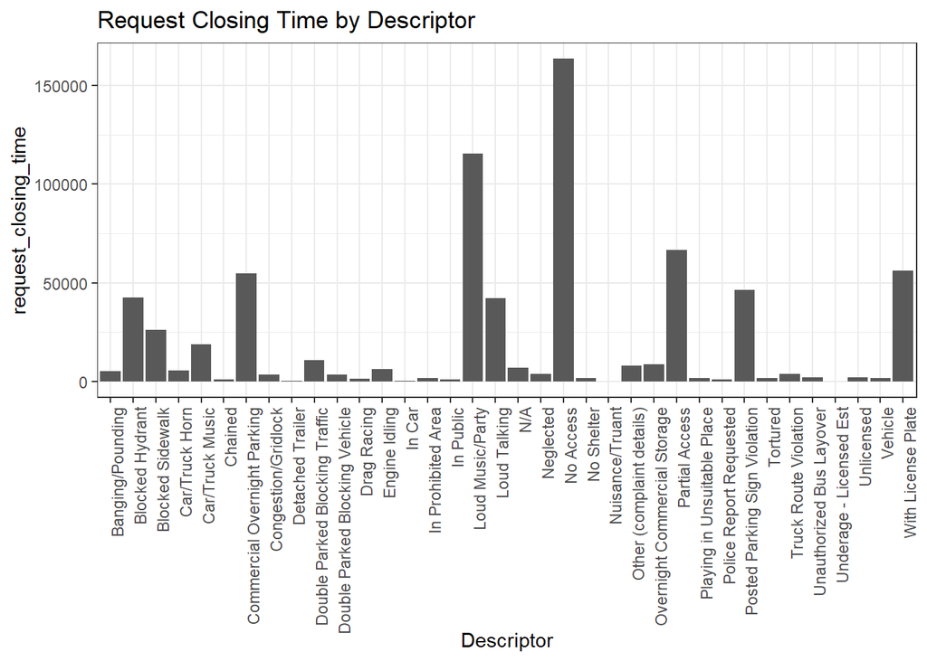

```r
ggplot(NYC, aes(x = Descriptor, y = request_closing_time)) +
  geom_bar(stat = 'identity') +
  labs(title = 'Request Closing Time by Descriptor') +
  theme_bw() +
  theme(axis.text.x = element_text(angle = 90, hjust = 1))
```

Also checking for the average of response time across descriptor is similar or not.

[figure not shown]

```r
avg_request_closing_time <- aggregate(request_closing_time ~ Descriptor, data = NYC, FUN = mean)
ggplot(avg_request_closing_time, aes(x = Descriptor, y = request_closing_time)) +
  geom_point(color = "blue") +
  geom_line(color = "blue", group = 1) +
  labs(title = 'Average Request Closing Time by Complaint Type', x = 'Descriptor', y = 'Avg_request_closing_time') +
  theme(axis.text.x = element_text(angle = 90, hjust = 1))
```

## Checking the relation of average request_closing_time with different locations.

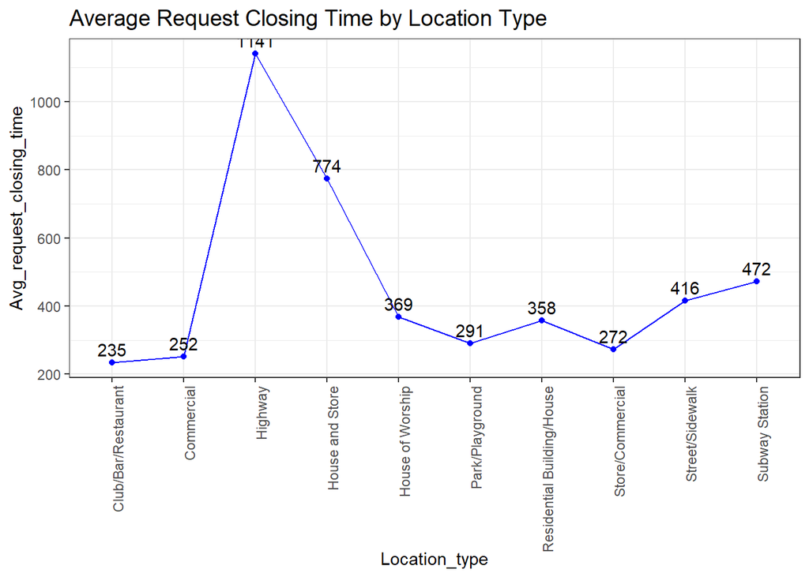

```r
avg_request_time <- aggregate(request_closing_time ~ Location_type, data = NYC, FUN = mean)
ggplot(avg_request_time, aes(x = Location_type, y = request_closing_time)) +
  geom_point(color = "blue") +
  geom_line(color = "blue", group = 1) +
  geom_text(aes(label = round(request_closing_time)), vjust = -0.5, color = "black") +
  labs(title = "Average Request Closing Time by Location Type",
       x = "Location_type", y = "Avg_request_closing_time") +
  theme_bw() +
  theme(plot.title = element_text(size = 14),
        axis.text.x = element_text(angle = 90, hjust = 1))
```